# N4006 Functions with Data - Closures in C (A Comprehensive Proposal Overviewing Blocks, Nested Functions, and Lambdas)

#### 3.2.5. Forward Declarations Work

Capture functions can be forward declared, similar to how GNU Nested Functions can be forward-declared if one uses the `auto` keyword in front of the definition of a Nested Functions:

```cpp
#include <stdlib.h>
#include <string.h>
#include <stddef.h>

int main(int argc, char* argv[]) {
  int in_reverse = 0;
  // forward-declared compare
  int compare(const void* untyped_left, const void* untyped_right) _Capture(in_reverse);
  // even though it is captured by value...

  if (argc > 1) {
    char* r_loc = strchr(argv[1], 'r');
    if (r_loc != NULL) {
      ptrdiff_t r_from_start = (r_loc - argv[1]);
      if (r_from_start == 1 && argv[1][0] == '-' && strlen(r_loc) == 1) {
        in_reverse = 1;
      }
    }
  }

  /*
  compare.in_reverse; // CONSTRAINT VIOLATION: cannot access until definition
  */

  int compare_trampoline(const void* untyped_left,
    const void* untyped_right,
    void* user)
  _Capture() {
    return (*(typeof(compare)*)user)(untyped_left, untyped_right);
  }

  int list[] = { 2, 11, 32, 49, 57, 20, 110, 203 };
  qsort_r(list, (sizeof(list)/sizeof(*list)), sizeof(*list),
    compare_trampoline,
    &compare
  );
  // define it here;
  // captures and arguments must be identical otherwise it is a violation
  // `in_reverse` is captured at the point of definition, not the point of declaration.
  int compare(const void* untyped_left, const void* untyped_right) _Capture(in_reverse) {
      const int* in_reverse = (const int*)user;
      const int* left = untyped_left;
      const int* right = untyped_right;
      return (*in_reverse) ? *right - *left : *left - *right;
  };
  return list[0];
}
```

Some important points for Capture Functions’s forward declarations:

- the values captured have their values taken at the point of definition, not at the point of declaration;
- because of this, one cannot use the `.` or the `->` operators on a capture function declaration, only a definition;
- and, forward declarations can only have the function call operation applied to them, before they are defined.

NOTE: It is unclear whether the Apple Blocks-like by-value capture should occur at the point of the first declaration or the definition. Currently, the reasoning is that using the definition for the values captured is better because there can be multiple forward declarations (in perhaps sprawling manners due to `#include` and other code copy-paste mechanisms) but only one definition, and thus the definition should be the important part.

NOTE: The other opinion is that restricting access to `.` and `->` is not worthwhile, and that capturing things by-value at the first forward declaration is good.

There is no existing practice for this due to the way GNU Nested Functions -- the only existing practice where forward-declaring the closure type is allowed -- work. That is, they only capture by-name/by-reference, and so the value is always the value at the point of closure invocation and not at the point of closure evaluation. Apple Blocks and other solutions do not have this problem since they are expressions and thus do not have to engage in any sort of work with the "split between declaration vs. definition" issue at all. Other solutions always capture by reference / by lvalue / by name, so they offer no insight.

#### 3.2.6. Forward Declarations without a name are a bit useless

Forward declarations without a name are a bit silly, because they are unique types. An unnamed declarator means that there’s a unique type that has been forward-declared but serves no other purpose:

```cpp
int main(int argc, char* argv[]) {
  typedef int (compare_closure1_t)(
    const void* untyped_left,
    const void* untyped_right
  ) _Capture(=);
  typedef int (compare_closure2_t)(
    const void* untyped_left,
    const void* untyped_right)
  _Capture(=);
  typedef compare_closure_t compare_closure1_t;
  typedef compare_closure_t compare_closure2_t; // constraint violation: not a compatible type redeclaration
  return 0;
}
```

The syntax is kept for parity with the rest of the declarator syntax. It also allows a user to make a unique type within a translation unit, though there are obviously other ways to do this that do not rely on such arcane knowledge. Nevertheless, we do not ban the construct since we just want this and everything surrounding it to work "as it would", even if the result is silly.

#### 3.2.7. Capable of Recursion

Capture Functions are able to refer to themselves for the purpose of recursion. This means that `__self_func` ([__self_func]), unlike for expression-based/unnamed Function Literals/Lambdas/Block literals, is not required:

```cpp
int main () {
  const int mult = 3;
  int tripling (int times, int start) _Capture(mult) {
    if (times >= 5) {
      return start;
    }
    return tripling(times + 1, start * mult); // normal recursion
  }
  return tripling(0, 1);
}
```

However, `__self_func` should still work in this code for consistency’s sake with the rest of where `__self_func` would be applicable (such as in regular function calls).

#### 3.2.8. Capable of Self-Call

Capture Functions are able to refer to themselves in the argument list, and that means it is possible to form a pointer to itself. While they are incomplete types until after the end of the `_Capture` list, the type is still there and thus taking a pointer to such a type and using it after the opening `{` thus results in using a complete type, though the usage is somewhat weird:

```cpp
int main () {
  const int mult = 3;
  int tripling (int times, int start, typeof(tripling)* self) _Capture(mult) {
    if (times >= 5) {
      return start;
    }
    return self[0](times + 1, start * mult, self);
    // or
    // return (*self)(times + 1, start * mult, self);
  }
  return tripling(0, 1, &tripling);
}
```

#### 3.2.9. Not An Expression

The one true technical downside is that Capture Functions are declarations / definitions. They cannot be used (without the Statement Expression extension) in a function call’s argument list, which means that (short) closures and anonymous functions still need the full function definition. This is annoying and, honestly, one of the reasons § 3.3 Lambdas are preferred as a shorthand syntax.

It also means that, without Statement Expressions, Capture Functions cannot be used for the implementation of many macros which are typically expected to be usable as normal expressions.

#### 3.2.10. Footgun: By-Name Capture Exceeds Captures’s Lifetime

A brief display of the undefined behavior:

```cpp
auto ub (int parameter) {
  int automatic = 7;
  int fn() _Capture(parameter, &automatic) {
    return parameter + automatic;
  }
  return fn; // well-defined copy return
  // but dangling reference to `automatic`!
}

int main () {
  auto fn = ub(2);
  return fn(); // undefined behavior:
  // `automatic` no longer exists.
}
```

In general, undefined behavior occurs in the same way that it occurs within existing C code: use of an object after its lifetime has ended (in this case, an automatic storage duration object has gone out-of-scope). The fix for `ub` in this case is to capture `automatic` by-value. This makes it safe to copy that function object to the heap, or the stack. Additionally, no UB is possible by conversion to a function pointer.

#### 3.2.11. Future Footgun: Wide Function Pointers

Wide function pointers, if and when they come to C, can make for footguns with capturing lambdas given that they will (likely) allow conversions from any Nested Function / Block / Lambda to them implicitly. Using a fictional wide function pointer syntax using `%`:

```cpp
typedef int foo_fn_t(int);

foo_fn_t% call_me (int x) {
  return [x](int y) { return x + y; }; // converts to wide function pointer type!
  // undefined behavior if the return value is ever
  // called outside of this function
}

int use_me(foo_fn_t% fn) {
  return fn(2);
}

int main () {
  int x = 30;
  return use_me(call_me(x));
}
```

This is a similar problem to Nested Functions returning a regular function pointer from a function call. Unfortunately, a conversion being allowed here is necessary to allow the 75%+ use case of passing it as a parameter, such as:

```cpp
typedef int foo_fn_t(int);

void pass_to_me (foo_fn_t% func);

int main () {
  int x = 30;
  pass_to_me(
    [x](int y) { return x + y; }
  ); // converts to wide function pointer type!
  return 0;
}
```

Thusly, in a future with a wide function pointer type, such a problem might be allowed. This is similar to the § 3.2.10 Footgun: By-Name Capture Exceeds Captures’s Lifetime. A special carveout in the specification for the return value case could be developed, but this would need work to avoid precluding useful cases.

### 3.3. Lambdas

Lambdas are simply a reskinned version of Capture Functions. They have all the same functionality, but with the benefits that they are:

- expressions, and therefore can be used in-line in a function call as an argument or as part of an argument;
- expressions, and therefore can be immediately invoked;
- and, C++-compatible in their design.

We are deliberately leaving these as the only three benefits of lambdas over Capture Functions for the sole reason that, after Capture Functions, Lambdas will be VERY minimal effort to support. The reason for that is that they are, semantically, just a "Syntactic Reskin" of Capture Functions, save for their presence as an expression.

```cpp
auto make_seven (int x) {
  int y = 7;
  return [x, y]() { return x * y; };
}

int main () {
  int x = 3;
  auto zero = [] () {
    // OK, no external variables used
    return 0;
  };
#if 0
  auto double_it = [] () {
    return x * 2; // constraint violation
  };
#endif
  auto triple_it = [x] () {
    return x * 3; // OK, x = 3 when called
  };
  auto quadruple_it = [&x] () {
    return x * 4; // OK, x = 5 when called
  };
  auto quintuple_it = [=] () {
    return x * 5; // OK, x = 3 when called
  };
  auto sextuple_it = [&] () {
    return x * 6; // OK, x = 5 when caled
  };
  x = 5;
  auto seven_tuple_it = make_seven(x);
  return zero() + triple_it() + quadruple_it()
    + quintuple_it() + sextuple_it() + seven_tuple_it();
  // return 109;
  // 0 + (3 * 3) + (5 * 4)
  // + (3 * 5) + (5 * 6)
  // + (5 * 7)
}
```

Given this, there is nothing else to write for this section: all of the benefits of Capture Functions (§ 3.2 Capture Functions: Rehydrated Nested Function) applies to these types in full, and just copying all of that text from one to another to say exactly the same thing is not important. We will instead just talk about the differences exclusively in comparison to Capture Functions in the next few sections.

#### 3.3.1. Lambdas are Expressions

```cpp
#include <stdlib.h>
#include <string.h>
#include <stddef.h>

static int in_reverse = 0;

int main(int argc, char* argv[]) {
  if (argc > 1) {
    char* r_loc = strchr(argv[1], 'r');
    if (r_loc != NULL) {
      ptrdiff_t r_from_start = (r_loc - argv[1]);
      if (r_from_start == 1 && argv[1][0] == '-' && strlen(r_loc) == 1) {
        in_reverse = 1;
      }
    }
  }
  int list[] = { 2, 11, 32, 49, 57, 20, 110, 203 };
  qsort(list, (sizeof(list)/sizeof(*list)), sizeof(*list),
    // expression, fits in-line
    [](const void* untyped_left, const void* untyped_right) {
      const int* left = (const int*)untyped_left;
      const int* right = (const int*)untyped_right;
      return (in_reverse) ? *right - *left : *left - *right;
    }
  );

  return list[0];
}
```

This also makes it **suitable for use in macros**, which is not something a regular Capture Functions can accomplish.

NOTE: This can be alleviated by using Statement Expressions, which would allow Capture Functions to work within typical macro contexts.

#### 3.3.2. Recursion Is Impossible

Unfortunately, it is impossible to call a lambda from within itself (not without C++'s feature "deducing this", which requires templates and other things to work), and therefore that is another disadvantage. It can be fixed with the proposed `__self_func` feature ([__self_func]):

```cpp
int main () {
  int tripling (int times, int start) {
    if (times >= 5) {
      return start;
    }
    return __self_func(times + 1, start * 3); // __self_func feature
  }
  return tripling(0, 1);
}
```

#### 3.3.3. Capable of Self-Call

Lambdas are able to refer to themselves in the argument list as they are object types. Unlike Capture Functions, which are incomplete during the argument list and complete after the `_Capture` specification, lambdas have their captures first. That means all the information to be a complete object is known by the time the argument list is opened. If `__self_func` is available ([__self_func]), this means one can use a "self" closure type without pointers or indirection:

```cpp
int main () {
  const int mult = 3;
  auto tripling = [mult](int times, int start, typeof(__self_func) self) {
    if (times >= 5) {
      return start;
    }
    return self(times + 1, start * mult, self);
  }
  return tripling(0, 1, &tripling);
}
```

This is, obviously, not recommended because this takes the object itself by value and so can do lots of unnecessary copies. But, it can be taken as either a full complete object or just a pointer to said object, so the choice is up to the user since Lambdas are complete object types by the function argument list.

#### 3.3.4. Trailing Return Types / Deduced Return Type

Finally, one may need to add the concept of a "trailing return type" to C in order to allow modifying the return type of a lambda. At the moment, the way a lambda with no specified return type works is that every single `return` statement must have exactly the same type (there is no negotiation for some "promoted" type or similar). That is, returning a `long` in one branch and an `int` in another branch is an error: they all must be cast to `int` or they all must be cast to `long`:

```cpp
int main () {
  auto okay0 = []() {
    if (1) {
      return 0;
    }
    else {
      return 0;
    }
  }(); // ok
  auto violation0 = []() {
    if (1) {
      return 0U;
    }
    else {
      return 0L;
    }
  }(); // constraint violation: different return types
  auto okay1 = []() {
    if (1) {
      return (unsigned long long)0U;
    }
    else {
      return (unsigned long long)0L;
    }
  }(); // ok: cast to identical types
  return 0;
}
```

This can be **extremely** annoying to deal with. Trailing return types fix this problem by allowing lambdas to use a trailing `-> type-name` to have the function return type become `type-name`:

```cpp
int main () {
  auto okay0 = []() {
    if (1) {
      return 0;
    }
    else {
      return 0;
    }
  }(); // ok
  auto violation0 = []() -> unsigned int {
    if (1) {
      return 0U;
    }
    else {
      return 0L;
    }
  }(); // now okay: fixed return type, conversions happen normally
  auto okay1 = []() {
    if (1) {
      return (unsigned long long)0U;
    }
    else {
      return (unsigned long long)0L;
    }
  }(); // ok: cast to identical types
  return 0;
}
```

This fixes other problems in the C language as well, such as not being able to specify functions with proper variable-length array returns without using ugly syntax. The `auto` part only applies for regular function definitions, and could also be applied to Capture Functions for ease-of-use (but is not required for it to function appropriately). One could also just have `auto` but no `->` to have regular functions achieve the lambda behavior, where all `return` expressions must evaluate to the exact same type. Not having a `return` or having a `return;` both imply the return type is `void`, and thus any other kind of `return <expr>;` in that function would be illegal.

#### 3.3.5. Forward-declaration is Impossible

It is impossible to forward-declare a lambda given the fact that every lambda is a definition of a unique object as an expression and does not do the usual declaration/definition split. Implementations may fold identical lambdas together but that is only observable as an optimization, and is not a guarantee of the design. This contrasts with Capture Functions, wherein they can be declared (with all of their captures) under a specific identifier in a specific scope and reserve that identifier for that type, and then later defined in that scope or a dependent scope.

That is the full set of notable technical differences between Lambdas and Capture Functions.

### 3.4. Capture Functions and Lambdas are Complete Objects

The most important change from typical GNU Nested Functions and mirroring behavior from C++ Lambdas is that capture functions and these C-style lambdas -- the identifier itself introduced by the definition of the function -- is a regular, normal, complete C object. This enables it to be:

- returned, if the type is knowable at the time of function definition (or `auto` return types are incorporated into the language);
- passed to a function, if the function is defined after the creation of the capture functions;
- and, stored elsewhere through static/`_Thread_local` data with assignment or `memcpy`, or even on the heap.

These are important qualities to allow these functions with data to be used with asynchronous code, as (stored) callbacks, and in other scenarios. The size and alignment of the object is implementation-defined, and its layout is also entirely implementation-defined, much like the properties of a regular `struct` or `union` type. This allows implementations to not have to figure out how to squash everything into a single erased type, and instead enforce the Single Responsibility Principle; they already know how to create unique types, they already know how to create and fill structure types, and now separately a wide function pointer type or a "make trampoline" compiler feature (§ 6.3 Make Trampoline and Singular Function Pointers) can be developed.

Given an extremely simple example:

```cpp
#include <stdlib.h>
#include <stdio.h>

typedef void work_fn_t(void* user);
void add_work(work_fn_t* work, void* user);
bool work_done();

void kickoff(int start, int limit) {
  void work() _Capture(start, limit) {
    printf("doing work for %d to %d\n", start, limit);
    for (int i = start; i < limit; ++i) {
      printf("sooo much work - %d\n", i);
    }
  }
  void work_trampoline(void* user) {
    (*((typeof(work)*)user))()
    // free lambda after work is done
    free(user);
  };
  // elevate to higher lifetime to survive async function call time
  void* work_ptr = malloc(sizeof(work));
  memcpy(work_ptr, &work, sizeof(work));
  add_work(work_trampoline, work_ptr);
}

int main (int argc, char* argv[]) {
  int start = 0;
  int limit = 30;
  if (argc > 1)
    start = atoi(argv[1]);
  if (argc > 2)
    limit = atoi(argv[2]);

  kickoff(start, limit);

  while (!work_done());
  // no memory leaks at the end of the program
  return 0;
}
```

There are caveats about this, but they are related to forward declarations (§ 3.2.5 Forward Declarations Work).

### 3.5. Mutability Problem

This proposal does not address the mutability issue of all captures being `const`-by-default. That required a new keyword in C++, `mutable`, to be applied to the lambda to allow captures to be modified by the function call. Another alternative is allowing type specifiers / qualifiers on the storage of these types, where `mutable` can be applied to allow for that specific capture to be updated as well as used.

We have not chosen a direction for this paper yet. This is something we can talk about in focused WG14 discussion, but the current attitude is to simply not bother until WG14 picks up the `mutable` keyword for the same reasons `mutable` exists in C++, which is to update certain parts of an e.g. `struct cache_t` type that is morally and spiritually `const` but has an internal field that needs to be updated to save computation for specific problems.

### 3.6. `restrict` Problem

Similar to the § 3.5 Mutability Problem issue, `restrict` cannot be added to individual captures. This means that pointers may lose the ability to assert they are not aliasing anything when copied into the captured structure.

NOTE: While this applies to essentially all qualifiers lost by l-value conversion, `_Atomic` as a qualifier does not mean the same thing, and therefore is safe from this problem.

We think the proper direction here would follow the same path as the ability to use `mutable`. A solution devised for that will cover this space as well; the ability to use type specifiers, qualifiers, and more on captures or the closure function/object type itself would solve many of these issues, and we think it is a worthwhile endeavor. But, such a change deviates from how captures work in existing practice, and therefore will not be directly added to the proposal until discussion is had.

### 3.7. Not `constexpr` Capable

The lambdas and capture functions here cannot be used to compute translation-time (compile-time) values. This is something to be explored only after further advancements of the Generalized Function Calls / `constexpr` Technical Specification ([constexpr-functions-ts]). It is alright if this is not `constexpr` at the moment, because no C functions can be `constexpr`. Whatever rules for `constexpr` functions appear from the TS, we would likely incorporate here by allowing the addition of a `constexpr` specifier for the closure’s function type.

## 4. Measuring Solution Spaces

One of the ways we can increase the confidence we have in our data is to provide benchmarks for the things we are working on proposing to the C standard. We do not mind adding new and improved functionality to the benchmarks to do more measurements it is an open set and we would appreciate any help in benchmarking or measuring or coming up with new ways to observe behavior.

### 4.1. Donald Knuth’s Man or Boy Test

This is a set of benchmarks using Donald Knuth’s Man or Boy program, which tests self-references and recursion in the same function / closure object. It also flexes a number of properties that can evaluate the quality of a closure implementation, and so is suitable as a microbenchmark. Both a linear version and a logarithmic version of the graphs are made available due to how the performance differences skew things wildly in one direction or another. The benchmark’s source code is available in the ztd.idk repository ([ztd-idk-closures-benchmark]).

#### 4.1.1. Methodology

The tests were ran on a 13-inch 2020 MacBook Pro M1. It has 16 GB of RAM and is on MacOS 15.7.2 Sequoia at the time the test was taken, using the stock MacOS AppleClang Compiler and the stock brew install gcc compiler in order to produce the numbers seen on December 28<sup>th</sup>, 2025.

The experimental setup used the Man or Boy test, but with the given `k` value loaded by calling a function in a DLL / Shared Object. The expected `k` value that the Man or Boy test is supposed to yield is also loaded from a DLL / Shared Object. This prevents optimizing out all recursion and doing enough ahead-of-time computation to simply collapse the benchmarked code into a constant-time, translation-time calculation. It ensures the benchmark is actually measuring the actual performance characteristics of the technique used, as all of them are computing from the same initial `k` value and all of them are expected to produce the same `expected_k` answer.

There 2 measures being conducted: Real ("wall clock") Time and CPU Time. The time is gathered by running a single iteration of the code within a `for` loop. That loop runs anywhere from a couple thousand to hundreds of thousands of times to produce confidence in that run of the benchmark, and each loop run is considered an individual iteration. The iterations are then averaged to produce the first point after there is confidence that the measurement is accurate and the benchmark is warm. The iteration process to produce a single mean was then repeated 150 times. All 150 means are used as the points for the values (shown as transparent dots) on the bar graph, and the average of all of those 150 means is then used as the height of a bar in a bar graph.

- no-op: Literally doing nothing. It’s just there to test environmental noise and make sure none of our benchmarks are so off-base that we’re measuring noise rather than computation. Helps keep us grounded in reality.
- Normal Functions: regular C functions which add an extra argument to the function call in order to pass more data. Somewhat similar in representation to rewriting `qsort` to `qsort_r`/`qsort_s` to pass a user data pointer.
- Normal Functions (Rosetta Code): regular C functions which add an extra argument to the function call in order to pass more data. Taken directly from the Rosetta Code weekly, and uses a pointer `int* k` to refer to an already-existing value of `k` during a series of recursive calls.
- Normal Functions (Static): regular C function which uses a static variable to pass the specific context to the next function. Not thread safe.
- Normal Functions (Thread Local): same as "Normal Functions (Static)" but using a `thread_local` variable instead of a `static` variable. Obviously thread safe.
- Lambdas (No Function Helpers): a solution using C++-style lambdas. Rather than using helper functions like `f0`, `f1`, and `f_1`, we compute a raw lambda that stores the value meant to be returned for the Man-or-Boy test (with a body of just `return i;`) in the lambda itself and then pass that uniquely-typed lambda to the core of the test. The entire test is templated and uses a fake recursion template parameter to halt the translation-time recursion after a certain depth.
- Lambdas: The same as above but actually using `int f0(void)`, etc. helper functions at the start rather than lambdas. Tries to reduce optimizer pressure by using “normal” types which do not add to the generated number of lambda-typed, recursive, templated function calls.
- Lambdas (`std::function_ref`): The same as above, but rather than using a function template to handle each uniquely-typed lambda like a precious baby bird, it instead erases the lambda behind a `std::function_ref<int(void)>`. This allows the recursive function to retain exactly one signature.
- Lambdas (`std::function`): The same as above, but replaces `std::function_ref<int(void)>` with `std::function<int(void)>`. This is an allocating, C++03-style type.
- Lambdas (Rosetta Code): The code straight out of the C++11 Rosetta Code Lambda section on the Man-or-Boy Rosetta Code implementation.
- Apple Blocks: Uses Apple Blocks to implement the test, along with the __block specifier to refer directly to certain variables on the stack.
- GNU Nested Functions (Rosetta Code): The code straight out of the C Rosetta Code section on the Man-or-Boy Rosetta Code implementation.
- GNU Nested Functions: GNU Nested Functions similar to the Rosetta Code implementation, but with some slight modifications in a hope to potentially alleviate some stack pressure if possible by using regular helper functions like `f0`, `f1`, and `f_1`.
- Custom C++ Class: A custom-written C++ class using a discriminated union to decide whether it’s doing a straight function call or attempting to engage in the Man-or-Boy recursion.
- C++03 shared_ptr (Rosetta Code): A C++ class using `std::enable_shared_from_this` and `std::shared_ptr` with a virtual function call to invoke the “right” function call during recursion.

Each bar graph has a black error bar at the end, representing the standard error of the measurements performed. At 150 iterations, the error bars (which are most easily understood and read in the linear graphs) are a decent visual approximation of whether or not two solutions are within a statistical threshold of one another.

MSVC was not tested because MSVC implements none of the extensions being tested, and we do not expect that its performance characteristics would be wildly different.

#### 4.1.2. Results

The result graphs are as follows, presented in four images for both MacOS ARM64 with Apple Clang 17 and GCC 15, and Windows AMD64 with Clang 21 and GCC 15:

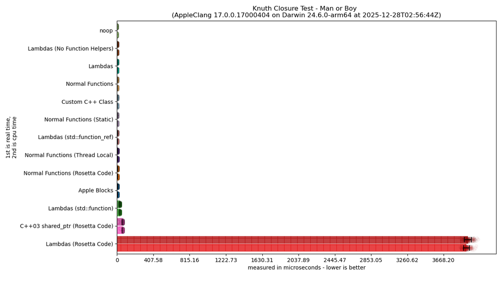

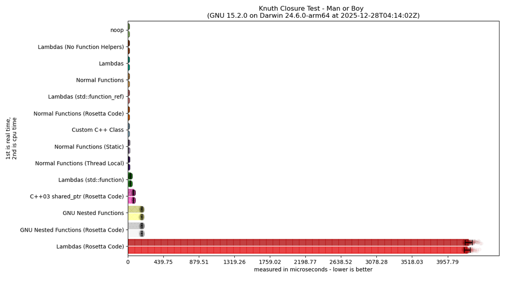

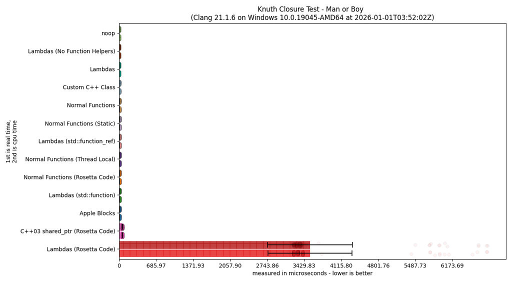

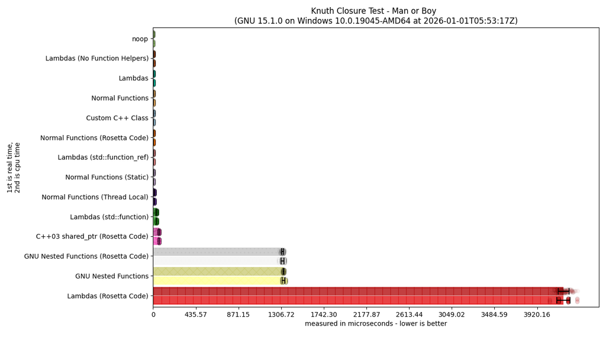

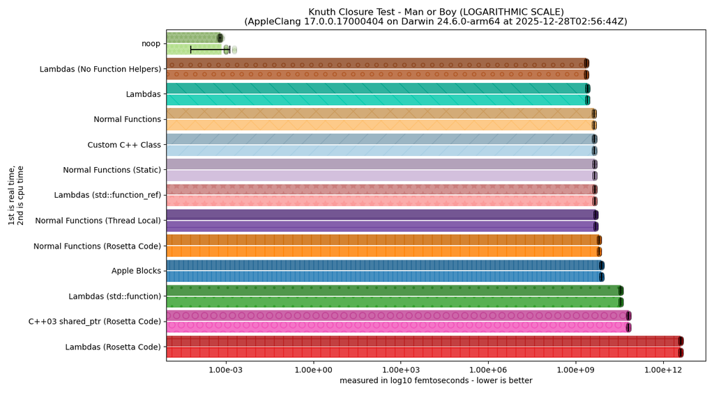

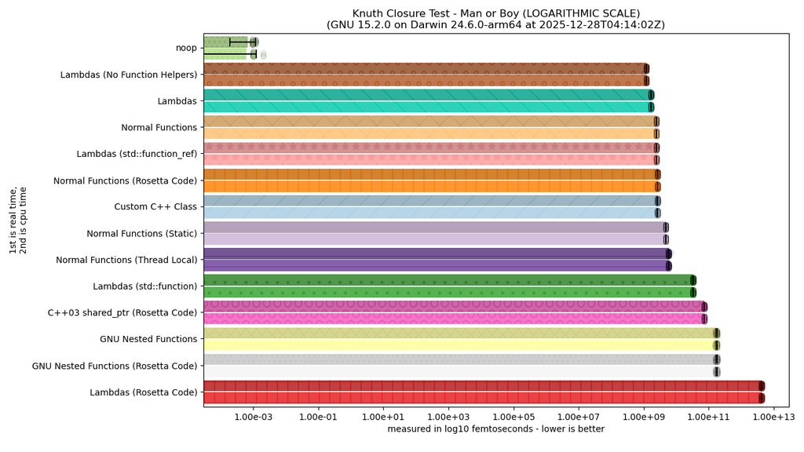

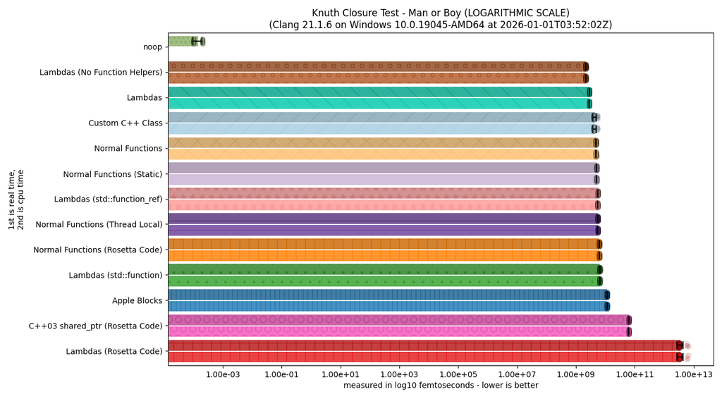

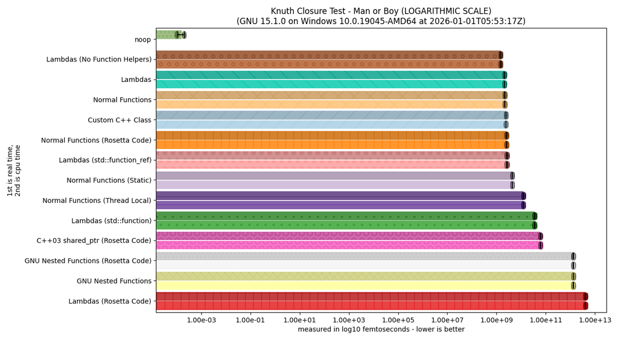

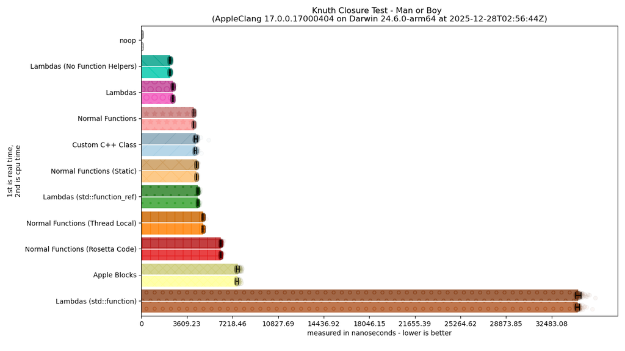

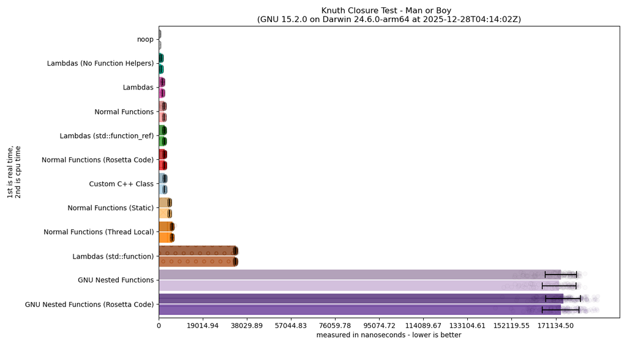

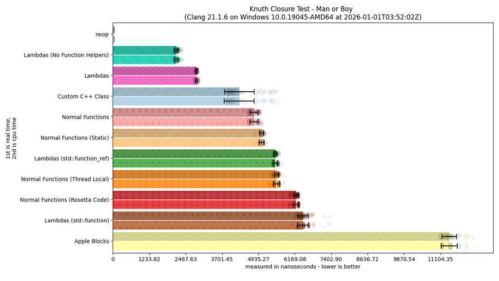

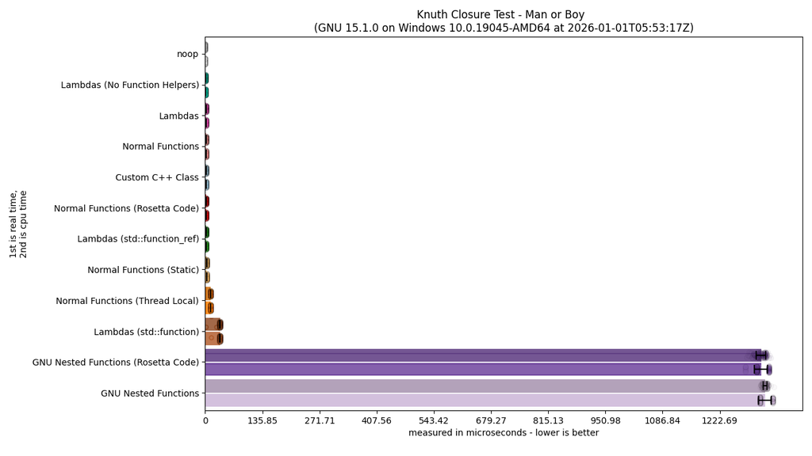

A full writeup is available at [closures-in-c-benchmark] and [closures-in-c-benchmark-followup] which includes methodology and other information about the tests.

### 4.2. Conclusions, Comparisons to Other Proposals, and Inferences

Note: A wide function pointer type is necessary no matter the solution chosen.

Note: A fixed, statically-known object that can be optionally type-erased behind a Wide Function Pointer seems optimal for even complex usages of closures in C.

Note: Apple Blocks and GNU Nested Functions have intrinsic design flaws that drastically impact their performance, meaning that even transporting a context pointer through a global variable with a normal C function is better.

Note: Manual management of closure pointer-to-function pointer trampolines may produce much better code generation and quality than implementation can currently handle, while allowing the user to have as much or as little security as possible.

In addition to the key takeaways above, some other details we have understood are as follows. C++-style lambdas have the capability to be both awful (Lambdas using the Rosetta Code technique) and powerful (Lambdas with Perfect Type Information). Both of these techniques are unusable as-is in C as the things that make them awful or great are tied not due to lambdas design but moreso how they are used (e.g., `std::function` abstractions or translation-time recursion prevention.) Normal C functions (storing the integer `k` by value) can achieve near-parity with C++-style Lambdas at their best in terms of performance. However, it requires the modification of the function signature, which may not be viable in all cases (such as calling already-compiled interfaces or working with FFI). The use of `static` and `thread_local` to pass information across function boundaries comes with an unshakeable and implicit cost. `thread_local` is -- for obvious reasons -- more expensive than just `static`, but both incur overhead.

After evaluating current industry extensions, we find them to be strangely poorly-performing despite being decades-old in some cases. Apple Blocks ([apple-blocks]) and similar heap-based solutions incur a fixed overhead due to the Blocks Runtime scheme, making it unsuitable for resource-constrained C environments. This means it is not worth pursuing this as a long-term solution in our technical opinion. GNU Nested Functions ([nested-functions]), as a quirk of its current most popular implementation, really inhibit inlining and other similar optimizations. A different implementation (e.g., the current `-ftrampoline-impl=heap` work that is currently available on 5 platforms in GCC trunk at time-of-writing) could be better. But, the fact that a typical quality of implementation provides such awful performance characteristics compared to every other solution despite being the oldest solution means that they too should be looked at skeptically for direct ISO C standardization. The heap-based trampolines of GNU Nested Functions also look like they may incur a similar fixed overhead just like the Apple Blocks implementation.

There may be a way to avoid this by simply reducing the context pointer and the actual function pointer to something more directly usable with the `__builtin_call_with_static_chain` intrinsic available in GCC and Clang ([builtin_call_with_static_chain_gcc]). We expect that the performance benefits here could be quite good, but this is not proven and not implemented yet, unlike Lambdas and other solutions which have plenty of implementation and perform well based on user choice of type erasure or allocation or storage.

The Function Literals and Local Functions ([n3678], [n3679]) proposals can have their performance approximated in their best-case as following the performance of the series of Normal Functions. This requires modifying the function signature. If the function signature isn’t modified, there isn’t really a point of comparison in these benchmarks other than falling back to other means of context transportation. All of these solutions vary wildly in performance, from Apple Blocks runtimes to various style of trampolines. This makes it impossible to understand Function Literals and Local Functions as solving the problem at hand, because they provide no plausible forward path on which to judge. Thus, we consider them as invalid solutions to this problem space.

Accessing the Context of Nested Functions ([n3654]), even in its later iterations, approximates either the Normal Functions (can modify the signature, best case) or GNU Nested Functions (([nested-functions], [n2661])) (creates an invisible trampoline to transport closure context, worst case) performance. We are unsure of how this would continue given the deeply negative impact given access to the current invocation’s stack frame / "function environment" is on the optimizer’s ability to push for performance. While we think there is potential for this, we believe explicitly or implicitly capturing just the data -- and not the environment or stack frame abstraction itself -- would result in better performance characteristics no matter the design.

Finally, any solution is going to need a Wide Function Pointer type in the C ecosystem to make it usable and worthwhile. In particular, Lambdas with `std::function_ref` is a directly applicable proxy to what "Capture Functions and Wide Function Pointers" and/or "Lambdas and Wide Function Pointers" could bring in terms of worst-case performance to the C ecosystem as a whole.

## 5. Wording

**THIS SECTION IS NOT GOING TO BE OFFICIAL UNTIL THE DESIGN SHAKEDOWN IS COMPLETE.**

NOTE: THIS PROPOSAL WILL ONLY INCLUDE LANGUAGE (CLAUSE 6) WORDING. LIBRARY WORDING WILL BE DONE AFTER THE LANGUAGE IS HANDLED, LIKELY IN A SEPARATE PROPOSAL.

### 5.1. `__self_func` Changes

#### 5.1.1. Modify "Predefined identifiers" (6.4.3.2)

- change the mention of "execution encoding" in this section to instead be "literal encoding (6.2.9)";
- and, add `constexpr` to the list of storage class specifiers for `static const char __func__[] = "function-name"`.

#### 5.1.2. Add the new keyword `__self_func` to §6.4.2

> **Syntax**

> <sup>1</sup> *keyword:* one of

> ...

> `__self_func`

#### 5.1.3. Add `__self_func` to the *primary-expression* grammar of §6.5.2

> **Syntax**

> <sup>1</sup> *primary-expression:*

> identifier

> constant

> string-literal

> ( expression )

> generic-selection

> `__self_func`

#### 5.1.4. Add a new section §6.5.2.✨ "`__self_func` after §6.5.2.1 "Generic selection"

> 6.5.2.✨ `__self_func`

> Constraints

> `__self_func` shall only appear in the body of an invocable, and refers to the innermost invocable scope it is inside.

> Semantics

> `__self_func` is either:
> - the lvalue of the closure (6.2.✨1) that it is contained within;
> - or, the function designator (6.3.3.1) designating and having the type of the function it is used in.

### 5.2. Core, Shared Changes

#### 5.2.1. Modify §6.2.1 "Scopes of identifiers, type names, and compound literals"

> 6.2.1 Scopes of identifiers, type names, and compound literals

> An identifier can denote:
> - a standard attribute, an attribute prefix, or an attribute name;
> - an object;
> - a function;
> - a closure;
> - a tag or a member of a structure, union, or enumeration;
> - a typedef name;
> - a label name;
> - a macro name;
> - or, a macro parameter.

> For each different entity that an identifier designates, the identifier is *visible* (i.e. can be used) only within a region of program text called its scope. Different entities designated by the same identifier either have different scopes or are in different name spaces. There are four kinds of scopes: function invocable , file, block, and function prototype. (A *function prototype* is a declaration of a function.)

> A label name is the only kind of identifier that has *function scope* *invocable scope* . It can be used (in a `goto` statement) anywhere in the function body of the invocable (6.2.✨0) in which it appears , and excluding the body of any nested invocables, unless otherwise specified. It is declared implicitly by its syntactic appearance (followed by a `:` and a statement). Each invocable body has an invocable scope that is separate from the invocable scope of any other invocable body. In particular, a label is visible in exactly one invocable scope (the innermost body in which it appears) and distinct invocable bodies may use the same identifier to designate different labels.

> ...

> NOTE Properties of the feature to which an identifier refers are not necessarily uniformly available within its whole scope of visibility. Examples are identifiers or functions with an incomplete type that is only completed in a subscope of its visibility, labels that are only valid targets of `goto` statements when the jump does not cross the scope of a VLA, identifiers of objects to which the access is restricted in specific contexts such as signal handlers or closures, or library features such as `setjmp` where the use is restricted to a specific subset of the grammar.

#### 5.2.2. Modify §6.2.5 "Types"

> 6.2.5 Types

> ...

> ...

> Any number of derived types can be constructed from the object and function types, as follows:

> — ...
> - A *function type* describes a function with specified return type. A function type is characterized by its return type and the number and types of its parameters. A function type is said to be derived from its return type, and if its return type is *T*, the function type is sometimes called "function returning *T*". The construction of a function type from a return type is called "function type derivation".
> - A *closure type* describes a structure or union type that is similar to a function with a specified or inferred return type (6.2.✨1). It is characterized by: its return type; the number, order, and type of its parameters; its lexical position in the program; and, the number, order, and type of its captures. The function type that has the same return type and list of parameter types as the closure type is the *closure’s function type*. A closure type is said to be derived from its function type’s return type and, if present, any of its captures. If its return type is *T*, the closure type is sometimes called "closure returning *T*" or "closure with captures returning *T*" (referring to closures with any number of captures, including zero captures).
> - ...

> These methods of constructing derived types can be applied recursively.

> ...

> A complete type shall have a size that is less than or equal to `SIZE_MAX`. A type has *known constant size* if it is complete and is not a variable length array type.

> An *invocable type* is either a closure type, a function type, or a pointer to function type (6.2.✨0).

> A *closure literal type* is a closure type characterized by having no captures. If its return type is *T*, the closure literal type is sometimes called "closure literal returning *T*" or "closure with no captures returning *T*". Closure literal types are a proper subset of the closure types.

> ...

#### 5.2.3. Modify §6.2.7 "Compatible type and composite type"

> 6.2.7 Compatible type and composite type

> ...

> A *composite type* can be constructed from two types that are compatible. If both types are the same type, the composite type is this type. Otherwise, it is a type that is compatible with both and satisfies the following conditions:
> - If both types are structure types or both types are union types, the composite type is determined recursively by forming the composite types of their members.
> - If both types are array types, the following rules are applied:
>   - If one type is an array of known constant length, the composite type is an array of that length.
>   - Otherwise, if one type is a variable length array whose length is specified, the composite type is a variable length array of that length.
>   - Otherwise, if one type is a variable length array of unspecified length, the composite type is a variable length array of unspecified length.
>   - Otherwise, both types are arrays of unknown length, and the composite type is an array of unknown length.

>   The element type of the composite type is the composite type of the two element types.
> - If both types are function types, the type of each parameter in the composite parameter type list is the composite type of the corresponding parameters.
> - If both types are closure types, the composite function type of the closure types' function types and the composite of the implementation-defined structure or union type of the closure types is the composite type of the two closure types.
> - If one of the types has a standard attribute, the composite type also has that attribute.
> - If both types are enumerated types, the composite type is an enumerated type.
> - If one type is an enumerated type and the other is an integer type other than an enumerated type, it is implementation-defined whether or not the composite type is an enumerated type.

> These rules apply recursively to the types from which the two types are derived.

#### 5.2.4. Add a new section §6.2.✨0 "Invocable", likely §6.2.10

> 6.2.✨0 Invocable

> Syntax

> *parameter-clause*:

> `(` *parameter-type-list*<sub>*opt*</sub> `)`

> Description

> An *invocable* is something with zero or more parameters (and possibly zero or more captures if it is a closure) that may be invoked/called to trigger an entry into and subsequent execution of an associated series of statements and/or expressions.

> Certain invocables can be declared (6.7.7) and potentially used before they are defined.

> Invocables are:
> - functions and pointers to functions (6.3.3.1, 6.5.3.3, 6.7.7.4, 6.9.2);
> - and, closures (6.2.✨1).

> The associated series of statements and/or expressions is called the *invocable body* or *body of the invocable*. The body of an invocable has its own scope, and that scope includes any captures it was created with and arguments it was invoked with. The scope that includes just the associated series of statements and/or expressions without the arguments or captures is called the *invocable statement list*. The scope in which an invocable is declared or defined is called the invocable’s *surrounding scope*, which is either the block scope of another invocable or file scope.

> As part of the declaration or definition of its parameter list, an invocable may include an ellipses in its list, either as the sole argument or at the end of its list. This is called a *variadic parameter*. Arguments supplied to an invocable whose positions match or come after the ellipses in the parameter list are its *varying arguments*. Any invocable which contains a variadic parameter is a *variadic invocable*. Additionally, functions with a variadic parameter are sometimes specifically called *variadic functions* and closures with a variadic parameter are sometimes specifically called *variadic closures*.

> Constraints

> Although variable length array types of unspecified size and incomplete types can be used as part of a parameter declaration for the declaration of an invocable, they shall not be used as part of a parameter declaration in the definition of an invocable.

> The only storage-class specifier that shall occur in a parameter declaration is `register`.

> After adjustment, the parameters in a parameter type list in an invocable declarator (such as a function declarator) that is part of a definition of that invocable shall not have incomplete type.

> Except for `void`, an invocable shall not specify a return type that is a function type, an array type, or an incomplete type.

> A parameter declaration shall not specify a `void` type, except for the special case of a single unnamed parameter of type `void` with no storage-class specifier, no type qualifier, and no following ellipsis terminator. If the parameter list consists of a single parameter of type `void`, the parameter declarator shall not include an identifier.

> Semantics

> An invocable can have a sequence of arguments passed to it that comply with the constraints and requirements of the invocable’s list of parameters. An invocable’s parameters have automatic storage duration.

> The identifier of the parameter, if any, is an lvalue in the invocable body. Variable length array types of unspecified size shall not be used as part of a parameter declaration in an invocable definition. The layout of the storage for parameters is unspecified. The type of each parameter is adjusted as described later in this subclause.

> NOTE A parameter that has no declared name is inaccessible within the invocable body. A parameter’s identifier cannot be redeclared in the invocable body except in an enclosed block. The visibility scope of a parameter in a function definition starts when its declaration is completed, extends to following parameter declarations, to possible attributes that follow the parameter type list, and then to the entire function body. The lifetime of each instance of a parameter starts when the declaration is evaluated starting a call and ends when that call terminates.

> The special case of an unnamed parameter of type `void` as the only item in the parameter list specifies that the function has no parameters.

> A declaration of a parameter as "array of *type*" shall be adjusted to "qualified pointer to *type*", where the type qualifiers (if any) are those specified within the `[` and `]`of the array type derivation. If the keyword `static` also appears within the `[` and `]` of the array type derivation, then for each call to the function, the value of the corresponding actual argument must provide access to the first element of an array with at least as many elements as specified by the size expression.

> If, in a parameter declaration, an identifier can be treated either as a typedef name or as a parameter name, it shall be taken as a typedef name.

> A declaration of a parameter as "function returning *type*" shall be adjusted to "pointer to function returning *type*", as in 6.3.3.1.

> If the invocable declarator is not part of a definition of that invocable, parameters can have incomplete type and can use the `[*]` notation in their sequences of declarator specifiers to specify variable length array types.

> The storage-class specifier in the declaration specifiers for a parameter declaration, if present, is ignored unless the declared parameter is one of the members of the parameter type list for the definition of the invocable. The optional attribute specifier sequence in a parameter declaration appertains to the parameter.

> On entry to the invocable, the size expressions of each variably modified parameter and typeof operators used in declarations of parameters are evaluated and the value of each argument expression is converted to the type of the corresponding parameter as if by assignment. (Array expressions and function designators as arguments were converted to pointers before the call.)

> After all parameters have been assigned, the invocable statement list is executed.

> Upon return to its invoker/caller from either finishing the execution of its body or returning, an invocable can either return nothing (indicated by the return type `void`) or return a value of object type (6.8.7.5). Unless otherwise specified, if the end of the invocable body is reached (such as the terminating `{`), and the value of the function call is used by the caller, the behavior is undefined.

#### 5.2.5. Add a new section §6.2.✨1 "Closures", after §6.2.✨0 "Invocables", likely §6.2.11

> 6.2.✨1 Closures

> 6.2.✨1.1 General

> Description

> A *closure* is a structure or union object of invocable type which has zero or more captures and zero or more parameters.

> A closure’s object is composed of at least any information necessary to invoke it with its arguments and for its implicit or explicit captures (6.2.✨1.2).

> Constraints

> Within the invocable body of a closure, identifiers shall be used according to the usual scoping rules. Captures and parameters can be accessed by their name in the invocable body. However, no identifier that is a variably modified type or an object of variably modified type shall be captured and used in the invocable statement list.

> An identifier that is an object of automatic storage duration which has a storage-class specifier of `constexpr` may also be used, but its address shall not be taken in the invocable body of the closure.

> An object of closure literal type shall be convertible to a function pointer.

> Semantics

> A closure with zero captures has closure literal type. Otherwise, it has closure type.

> A closure literal is convertible to a function pointer. That function pointer is the same for every closure literal of that closure literal type. An invocation of that function pointer invokes the associated body of that closure with the provided arguments.

> A closure’s size, layout, and representation are all implementation-defined unless otherwise specified. Each closure’s type is unique, and is characterized by:
> - any captures it can have;
> - the function type it has, particularly any parameters it can have and its return type;
> - and, the lexical position of the first declaration and/or definition.

> A closure’s type is not required to be compatible with any other type, unless otherwise specified.

> NOTE Two closures with identical captures and parameter types are not necessarily compatible (e.g. assignable) to one another.

> Unless otherwise specified for the associated closure, each captured value can be accessed with the member access operator `.` on that closure, or with the member access operator `->` on a pointer to that closure, using the capture’s name. The layout of the storage for the captures of a closure is implementation-defined.

> NOTE While accessing captures uses the member access operators, there is no requirements or constraints on what the actual members, layout, and other details of a closure is.

> 6.2.✨1.2 Captures

> Syntax

> *capture-list*

> *capture-default*

> *capture-name-list*

> *capture-default* `,` *capture-name-list*

> *capture-name-list*:

> *capture*

> *capture-name-list* `,` *capture*

> *capture-default*:

> `=`

> `&`

> *capture*:

> `&`<sub>opt</sub> *identifier* *capture-rename*<sub>*opt*</sub>

> *capture-rename*:

> `=` *assignment-expression*

> Description

> "Capturing" an object or a "captured" object describes the process of making visible objects from a surrounding scope visible in an inner, more nested invocable scope.

> A *capture list* allows access to objects visible in a certain scope named by the capture’s identifier or computed by the optional capture rename. A *capture* is an entry in the capture list.

> The `=` capture default is a *default value capture*. The `&` capture default is a *default reference capture*. Either one is called a *default capture*. The identifier in a capture is the *capture name*. The optional capture rename is the *capture initialization expression*. A capture with no capture initialization expression is called a *identifier capture*. A capture with a capture initialization expression is called an *expression capture*.

> If present, the closure which the capture partly characterizes and modifies is called the *associated closure*. The capture list’s *associated scope* is the surrounding scope of the associated closure unless otherwise specified.

> A capture name with no preceding `&` is called a *value capture*. A capture name preceded by a `&` is called a *reference capture*.

> Constraints

> The capture name shall appear at most once across the capture list and, if present, the parameter names of an associated closure. If the capture list’s associated scope is file scope, then no captures or default captures are permitted in the list.

> For a capture that is a reference capture and an identifier capture, the identifier shall be an object which is addressable. For a capture that is a reference capture and an expression capture, the capture initialization expression shall be an addressable lvalue.

> For an identifier capture, the capture name shall be a visible identifier of automatic storage duration from the associated scope.

> If a default value capture is specified, then subsequent captures shall only be reference captures. If a default reference capture is specified, then subsequent captures shall only be value captures.

> The type of the capture shall not be a variably modified type.

> NOTE Parameters of variably modified type are allowed to be captured because their type after adjustment is a pointer type.

> Semantics

> Capture lists are evaluated when their associated closure is defined and evaluated. The order of evaluation for captures are sequenced in order of declaration. The capture name is complete after its optional capture initialization expression. An earlier capture may occur within the capture initialization expression of a later capture.

> Value captures provide the value at time of evaluation of the capture when used. It is either the value of the identifier it refers to if it is an identifier capture, or the value of the capture initialization expression used to compute it if it is an expression capture. Unless otherwise specified, value captures have either:
> - the storage duration of an associated closure (if present);
> - or, automatic storage duration.

> NOTE A possible implementation of value captures is having a stored member in the closure object that is accessed every time it is used within the associated closure.

> Reference captures are lvalues that either:
> - refer to an identifier which exists in the surrounding scope identified by the capture name (if it is an identifier capture);
> - or, to the addressable lvalue of the capture initialization expression at the time of evaluation (if it is an expression capture).

> If a reference capture is used after the lifetime of what it refers to or addresses finishes, the behavior is undefined.

> NOTE A possible implementation of reference captures is storing a value capture of the address of the desired addressable lvalue in the closure object, and automatically dereferencing it upon its use in the associated closure.

> If a default capture is present, then it behaves as if all automatic storage duration objects visible in the surrounding scope are:
> - value captured, for `=`;
> - or, reference captured, for `&`.

> For a capture, let *T*<sub>*capture-initial*</sub> be:
> - `typeof(identifier)`, where `identifier` is the capture name if it is identifier capture;
> - or, the type of the capture initialization expression if it is an expression capture.

> Let *T*<sub>*capture*</sub> be the type of the capture after lvalue, array-to-pointer, or function designator to pointer conversion is applied to *T*<sub>*capture-initial*</sub>. The type of a capture is `Tcapture const`, unless otherwise specified.

> NOTE A capture therefore will not have array type itself, but a member of the captured type can possibly have array type.

> Recommended practice

> If all captures in a capture list are reference captures, implementations are encouraged to take advantage of potential layout and storage optimizations which respect to the lifetime of any associated closure.

#### 5.2.6. Modify §6.3.3.1 "Lvalues, arrays, and function designators"

> 6.3.3.1 Lvalues, arrays, and function designators

> ...

> A *function designator* is an expression that has function invocable type. Except when it is the operand of the `sizeof` operator, a typeof operator, or the unary `&` operator, a function designator with type "function returning *type*" is converted to an expression that has type "pointer to function returning *type*" :
> - "function returning *R*";
> - or, "closure literal returning *R*",

> is converted to an expression that has type "pointer to function returning *R*", where "*R*" is the return type.

#### 5.2.7. Modify §6.5.3.3 "Function calls"

In order,

1. Replace the title "Function calls" with "Invocation"
2. Outside the EXAMPLE and NOTE text, replace every instance of "type pointer to function" with "invocable type".
3. Outside the EXAMPLE and NOTE text, replace every instance of "function type" with "invocable type".
4. Outside the EXAMPLE and NOTE text, replace every instance of "a function" with "an invocable".
5. Outside the EXAMPLE and NOTE text, replace every instance of "function" with "invocable", EXCEPT:
   - "... ellipses in a variadic function declarator (6.7.7.4) ..." becomes "... ellipsis notation in a variadic invocable (6.2.✨0) ..."
6. Add a new description section before the Constraints:

   > **Description**

   > <sup>1</sup> Invocation, sometimes referred to as a "function call", "invocable call", "closure call", "function invocation", or "closure invocation", refers to calling an invocable (e.g. a function or (closure) object) and triggering the execution of the invocable’s statement list, as described in 6.2.✨0.

#### 5.2.8. Modify §6.5.5 "Cast operators"

> 6.5.5 Cast operators

> Constraints

> ...

> A pointer type shall be converted only to `void`, an integer type, or a pointer type. Only a pointer, integer, closure literal or `nullptr_t` type shall be converted to a pointer type. The type `nullptr_t` shall not be converted to any type other than `void`, `bool` or a pointer type. If the target type is `nullptr_t`, the cast expression shall be a null pointer constant or have type `nullptr_t`. A closure literal type shall not be converted to any pointer type other than a pointer to the closure’s function type.

> Semantics

> ...

#### 5.2.9. Modify §6.5.17.2 "Simple assignment"

> 6.5.17.2 Simple assignment

> Constraints

> One of the following shall hold:
> - the left operand has atomic, qualified, or unqualified arithmetic type, and the right operand has arithmetic type;
> - the left operand has an atomic, qualified, or unqualified version of a structure or union type compatible with the type of the right operand;
> - the left operand has atomic, qualified, or unqualified pointer type, and (considering the type the left operand would have after lvalue conversion) both operands are pointers to qualified or unqualified versions of compatible types, and the type pointed to by the left operand has all the qualifiers of the type pointed to by the right operand;
> - the left operand has atomic, qualified, or unqualified pointer type, and (considering the type the left operand would have after lvalue conversion) one operand is a pointer to an object type, and the other is a pointer to a qualified or unqualified version of `void`, and the type pointed to by the left operand has all the qualifiers of the type pointed to by the right operand;
> - the left operand has atomic, qualified, or unqualified pointer type, and (considering the type the left operand would have after lvalue conversion) one operand is a pointer to a function type, and the other is a closure literal type whose function type is compatible with the left’s pointed to function type;
> - the left operand has an atomic, qualified, or unqualified version of the `nullptr_t` type and the right operand is a null pointer constant or its type is `nullptr_t`;
> - the left operand is an atomic, qualified, or unqualified pointer, and the right operand is a null pointer constant or its type is `nullptr_t`; or
> - the left operand has type atomic, qualified, or unqualified `bool`, and the right operand is a pointer or its type is `nullptr_t`.

#### 5.2.10. Remove §6.7.7.4 "Function declarators" to rewrite in a new version it in terms of invocables

> 6.7.7.4 Function declarators

> Description

> If, in the declaration "`T D1`", `D1` has the form

> `D` *parameter-clause* *attribute-specifier-sequence*<sub>*opt*</sub>

> and the type specified for ident in the declaration "`T D`" is "*derived-declarator-type-list* `T`", then it is an invocable declarator (6.2.✨0) and the type specified for *ident* is "*derived-declarator-type-list* function returning the unqualified, non-atomic version of `T`".

> Semantics

> The optional attribute specifier sequence appertains to the function type.

> Two function types are compatible if and only if all of the following hold:
> - They specify compatible return types.
> - The parameter type lists agree in the number of parameters and in whether the function is variadic or not.
> - The corresponding parameters have compatible types.

> In the determination of type compatibility and of a composite type, each parameter declared with function or array type is taken as having the adjusted type and each parameter declared with qualified type is taken as having the unqualified version of its declared type.

> EXAMPLE The declaration

> ```cpp
> int f(void), *fip(), (*pfi)();
> ```

> declares a function `f` with no parameters returning an `int`, a function `fip` with no parameters returning a pointer to an `int`, and a pointer `pfi` to a function with no parameters returning an `int`. It is especially useful to compare the last two. The binding of `*fip()` is `*(fip())`, so that the declaration suggests, and the same construction in an expression requires, the calling of a function `fip`, and then using indirection through the pointer result to yield an `int`. In the declarator `(*pfi)()`, the extra parentheses are necessary to indicate that indirection through a pointer to a function yields a function designator, which is then used to call the function; it returns an `int`.

> If the declaration occurs outside of any function, the identifiers have file scope and external linkage. If the declaration occurs inside a function, the identifiers of the functions `f` and `fip` have block scope and either internal or external linkage (depending on what file scope declarations for these identifiers are visible), and the identifier of the pointer `pfi` has block scope and no linkage.

> EXAMPLE The declaration

> ```cpp
> int (*apfi[3])(int *x, int *y);
> ```

> declares an array `apfi` of three pointers to functions returning `int`. Each of these functions has two parameters that are pointers to `int`. The identifiers `x` and `y` are declared for descriptive purposes only and go out of scope at the end of the declaration of `apfi`.

> EXAMPLE The declaration

> ```cpp
> int (*fpfi(int (*)(long), int))(int, ...);
> ```

> declares a function `fpfi` that returns a pointer to a function returning an `int`. The function `fpfi` has two parameters: a pointer to a function returning an `int` (with one parameter of type `long int`), and an `int`. The pointer returned by `fpfi` points to a function that has one int parameter and accepts zero or more additional arguments of any type.

> EXAMPLE The following prototype has a variably modified parameter.

> ```cpp
> void addscalar(int n, int m, double a[n][n*m+300], double x);
>
> int main(void)
> {
>   double b[4][308];
>   addscalar(4, 2, b, 2.17);
>   return 0;
> }
>
> void addscalar(int n, int m, double a[n][n*m+300], double x)
> {
>   for (int i = 0; i < n; i++)
>     for (int j = 0, k = n*m+300; j < k; j++)
>       // a is a pointer to a VLA with n*m+300 elements
>       a[i][j] += x;
> }
> ```

> EXAMPLE The following are all compatible function prototype declarators.

> ```cpp
> double maximum(int n, int m, double a[n][m]);
> double maximum(int n, int m, double a[*][*]);
> double maximum(int n, int m, double a[ ][*]);
> double maximum(int n, int m, double a[ ][m]);
> ```

> as are:

> ```cpp
> void f(double (* restrict a)[5]);
> void f(double a[restrict][5]);
> void f(double a[restrict 3][5]);
> void f(double a[restrict static 3][5]);
> ```

> The last declaration also specifies that the argument corresponding to a in any call to `f` can be expected to be a non-null pointer to the first of at least three arrays of 5 `double`s, which the others do not.

*📝 IMPORTANT Editor’s Note: Undefined Behavior List J.2 references 6.7.7.4 -- change to 6.2.✨0.*

#### 5.2.11. Modify §6.8 "Statements and blocks"'s §6.8.1 "General" for blanket jump/label banning

> 6.8 Statements and blocks

> 6.8.1 General

> Constraints

> Unless otherwise specified, every jump and label is associated with the innermost invocable body it is contained within. Nested declarations or definitions of invocable bodies shall not refer to jump, iteration, or labeled statements in the invocable’s surrounding scope and shall only refer to a visible label or statement in the body of the associated invocable’s scope.

> Semantics

> A *statement* specifies an action to be performed. Except as indicated, statements are executed in sequence. The optional attribute specifier sequence appertains to the respective statement.

#### 5.2.12. Modify §6.8.3 "Compound Statement"

> 6.8.3 Compound Statement

> Semantics

> A *compound statement* that is a function body invocable body together with the parameter type list and the optional attribute specifier sequence between them forms the block associated with the function definition or closure definition in which it appears. Otherwise, it is a block that is different from any other block. A label that is not followed by another label or an unlabeled statement shall be translated as if it were followed by a null statement.

#### 5.2.13. Rewrite §6.9.2 "Function definitions" in terms of Invocables

> 6.9.2 Function definition

> Description

> A function definition defines (or declares and defines) the invocable body of a function call. Its surrounding scope is always file scope, even if a function declarator at block scope is the first encountered declaration of such a function.

> Constraints

> The identifier declared in a function definition (which is the name of the function) shall have a function type, as specified by the declarator portion of the function definition.

> The storage-class specifier, if any, in the declaration specifiers shall be either `extern` or `static`.

> Semantics

> The optional attribute specifier sequence in a function definition appertains to the function.

> The declarator in a function definition specifies the name of the function being defined and the types (and optionally the names) of all the parameters; the declarator also serves as a function prototype for later calls to the same function in the same translation unit. The type of each parameter is adjusted as described in 6.2.✨0.

> NOTE In a function definition, the return type of the function and its prototype cannot be inherited from a typedef:

> ```cpp
> typedef int F(void);
> // type F is "function with no parameters returning int"
>
> F f, g;                      // f and g both have type compatible with F
> F f { /* ... */ }            // WRONG: syntax/constraint error
> F g() { /* ... */ }          // WRONG: declares that g returns a function
> int f(void) { /* ... */ }    // RIGHT: f has type compatible with F
> int g() { /* ... */ }        // RIGHT: g has type compatible with F
> F *e(void) { /* ... */ }     // e returns a pointer to a function
> F *((e))(void) { /* ... */ } // same: parentheses irrelevant
> int (*fp)(void);             // fp points to a function that has type F
> F *Fp;                       // Fp points to a function that has type F
> ```

> EXAMPLE In the following:

> ```cpp
> extern int max(int a, int b)
> {
>   return a > b ? a: b;
> }
> ```

> `extern` is the storage-class specifier and `int` is the type specifier; `max(int a, int b)` is the function declarator; and `{ return a > b ? a: b; }` is the function body.

> EXAMPLE To pass one function to another, one can say

> ```cpp
> int f(void);
> /* ... */
> g(f);
> ```

> Then the definition of `g` can read

> ```cpp
> void g(int (*funcp)(void))
> {
>   /* ... */
>   (*funcp)(); /* or funcp(); */
> }
> ```

> or, equivalently,

> ```cpp
> void g(int func(void))
> {
>   /* ... */
>   func(); /* or (*func)(); */
> }
> ```

### 5.3. Lambda Expression Changes

#### 5.3.1. Add *lambda-expression* to the *postfix-expression* grammar of §6.5.3.1

> **Syntax**

> <sup>1</sup> *postfix-expression:*

> *primary-expression*

> *postfix-expression* `[` *expression* `]`

> *postfix-expression* `(` *argument-expression-list*<sub>*opt*</sub> `)`

> *postfix-expression* `.` *identifier*

> *postfix-expression* `->` *identifier*

> *postfix-expression* `++`

> *postfix-expression* `--`

> *compound-literal*

> *lambda-expression*

#### 5.3.2. Add a new section §6.5.3.✨ "Lambda expressions" somewhere after §6.5.3.4 "Structure and union members", likely §6.5.3.5

> 6.5.3.✨ Lambda expressions

> Syntax

> *lambda-expression*:

> *terse-capture-clause* *attribute-specifier-sequence*<sub>*opt*</sub> *parameter-clause*<sub>*opt*</sub> *attribute-specifier-sequence*<sub>*opt*</sub> *trailing-return-clause*<sub>*opt*</sub> *function-body*

> *terse-capture-clause*:

> `[` *capture-list*<sub>*opt*</sub> `]`

> *trailing-return-clause*:

> `->` *type-name*

> Description

> A lambda expression (or just "lambda") creates a closure definition that is immediately usable as an invocable. It is introduced and partly characterized by the terse capture clause, has parameters listed in the optional parameter clause, and has a surrounding scope of either:
> - the block scope at the lexical position within an invocable;
> - or, file scope.

> Constraints

> If a lambda or pointer to lambda is the first operand of the `.` operator or `->` operator, respectively, the second operand shall only specify a capture name from that lambda’s capture clause as the identifier to designate a member.

> If the trailing return clause is specified, the return type of the lambda is the specified type name. Otherwise, the return type is inferred from the body of the lambda expression. If the return type is inferred, then:
> - all `return` statements shall have an expression which is the exact same type of any one `return` statement’s an expression;
> - or, `void` if there is no expression for all the return statements or there are no return statements.

> Semantics

> The optional attribute specifier sequence in a lambda expression appertains to the resulting lambda type and to its function type. If the parameter clause is omitted, and parameter clause of the form `()` is assumed.

> EXAMPLE In following lambda object initialization:

> ```cpp
> int main () {
>   [[deprecated]] auto f = []() [[unsequenced]] {
>     return 2;
>   }
>   return f();
> }
> ```

> `[[unsequenced]]` describes the properties of the invocable body through its its function type, while `[[deprecated]]` applies to the closure object `f` and a diagnostic is encouraged at the invocation of `f` in `return f()`.

> Similar to a function definition, a lambda expression forms a single block that comprises all of its parts. Each capture and parameter has a scope of visibility that starts immediately after its definition is completed and extends to the end of the lambda body. Captures and parameters are visible throughout the body of a lambda unless they are redeclared in an inner block within that lambda’s body.

> Value captures have the same storage duration as the lambda. Value captures are initialized and formed during the evaluation of the lambda expression, and are tied to that specific lambda expression’s closure. Each invocation to the formed lambda creates a new instance of each parameter, similar to a function call. The layout of the storage for parameters is unspecified.

> The behavior is undefined if the lifetime of the lvalue referred ends and the reference capture is used.

> EXAMPLE Non-capturing lambdas can be immediately converted to function pointers, which makes them usable in functions such as `qsort`:

> ```cpp
> #include <stdlib.h>
>
> int main(int argc, char* argv[]) {
>   int list[] = { 2, 11, 32, 49, 57, 20, 110, 203 };
>   qsort(list, _Countof(list), sizeof(*list),
>     []() (const void* untyped_left, const void* untyped_right) {
>       const int* left = untyped_left;
>       const int* right = untyped_right;
>       return *left - *right;
>     }
>   );
>
>   return list[0]; // return 2;
> }
> ```

### 5.4. Capture Function Changes

#### 5.4.1. Add *capture-function-declarator* to the *direct-declarator* grammars of §6.7.7.1 "General" of "Declarators"

> 6.7.7.1 General

> Syntax

> ...

> *direct-declarator*:

> *identifier* *attribute-specifier-sequence*<sub>*opt*</sub>

> `(` *declarator* `)`

> *array-declarator* *attribute-specifier-sequence*<sub>*opt*</sub>

> *function-declarator* *attribute-specifier-sequence*<sub>*opt*</sub>

> *capture-function-declarator* *attribute-specifier-sequence*<sub>*opt*</sub>

> ...

> ...

#### 5.4.2. Add a new section §6.7.7.✨ "Capture function declarators" somewhere after §6.7.7.4 "Function declarators", likely becoming §6.7.7.5

> 6.7.7.✨ Capture function declarators

> Syntax

> *capture-function-declarator*:

> *direct-declarator* *parameter-clause* *function-capture-clause*

> *function-capture-clause*:

> `_Capture` `(` *capture-list*<sub>*opt*</sub> `)`

> Description

> A capture function declarator declares a closure object. It is introduced similarly to a function declarator but is characterized by the function capture clause as well as its lexical position, and has a surrounding scope of either:
> - the block scope at the lexical position within an invocable;
> - or, file scope.

> Constraints

> The identifier declared in a capture function declarator (which is the name of the capture function) shall have closure type, as specified by the declarator portion of the capture function declarator.

> A capture function object that is declared but not yet defined (6.9.✨) shall not have the member access operators `.` on the object or `->` the a pointer to that object applied to it.

> Semantics

> If, in the declaration "`T D1`", `D1` has the form

> `D` *parameter-clause* *function-capture-clause* *attribute-specifier-sequence*<sub>*opt*</sub>

> and the type specified for the identifier *ident* in the declaration "`T` `D`" is "*derived-declarator-type-list* `T`", then the type specified for *ident* is "*derived-declarator-type-list* closure with *function-capture-clause* captures returning the unqualified, non-atomic version of `T`". The type is complete after the end of the function capture clause. The optional attribute specifier sequence appertains to the closure’s function type.

> The second optional attribute specifier sequence after the parameter type list appertains to the closure object.

> EXAMPLE In following capture function declaration and definition:

> ```cpp
> int main () {
>   [[unsequenced]] int f () _Capture() [[deprecated]] {
>     return 2;
>   }
>   return f();
> }
> ```

> `[[unsequenced]]` appertains to and describes the properties of the invocable body through its its function type, while `[[deprecated]]` appertains and applies to the closure object `f` and a diagnostic is encouraged at the invocation of `f` in `return f()`.

#### 5.4.3. Add *capture-function-abstract-declarator* to the *direct-abstract-declarator* grammars of §6.7.8 "Type names"

> 6.7.8 Type names

> Syntax

> ...

> *direct-abstract-declarator*:

> `(` *abstract-declarator* `)`

> *array-abstract-declarator* *attribute-specifier-sequence*<sub>*opt*</sub>

> *function-abstract-declarator* *attribute-specifier-sequence*<sub>*opt*</sub>

> *capture-function-abstract-declarator* *attribute-specifier-sequence*<sub>*opt*</sub>

> ...

> *capture-function-abstract-declarator*:

> *direct-abstract-declarator*<sub>*opt*</sub> *parameter-clause* *function-capture-clause*

> Semantics

> In several contexts, it is necessary to specify a type. This is accomplished using a type name, which is syntactically a declaration for a function or an object of that type that omits the identifier. The optional attribute specifier sequence in a direct abstract declarator appertains to the preceding array or function type. The attribute specifier sequence affects the type only for the declaration it appears in, not other declarations involving the same type.

> EXAMPLE The constructions

> ```cpp
> (a)	int
> (b)	int *
> (c)	int *[3]
> (d)	int (*)[3]
> (e)	int (*)[*]
> (f)	int *()
> (g)	int (*)(void)
> (h)	int (*const [])(unsigned int, ...)
> (i)	int (*)() _Capture(&)
> (j)	int (*const [])(unsigned int, ...) _Capture(=)
> ```

> name respectively the types

> (a) `int`,

> (b) pointer to `int`,

> (c) array of three pointers to `int`,

> (d) pointer to an array of three `int`s,

> (e) pointer to a variable length array of an unspecified number of `int`s,

> (f) function with no parameters returning a pointer to `int`,

> (g) pointer to function with no parameters returning an `int`, and

> (h) array of an unspecified number of constant pointers to functions, each with one parameter that has type `unsigned int` and an unspecified number of other parameters, returning an `int`.

> (i) pointer to closure which takes no parameters and default captures the current scope by reference, returning an `int`.

> (j) array of an unspecified number of constant pointers to closures, which take an `unsigned int`, an unspecified number of other parameters, and default captures by value of the current scope, returning an `int`.

> The constructions (i) and (j), while valid types, are nonsensical as the lexical position of the abstract declarator for such a types makes it unique, regardless of the similarity of captures and function types of the closure type. Such a type may not be meaningfully useful in the program’s text for interacting with closures and closure types.

> NOTE As indicated by the syntax, empty parentheses in a type name are interpreted as "function with no parameters", rather than redundant parentheses around the omitted identifier.

#### 5.4.4. Modify §6.8.3 "Compound statements" and add a new grammar production for "*block-item*"

> 6.8.3 Compound statements

> Syntax

> ...

> *block-item*:

> *declaration*

> *function-definition*

> *capture-function-definition*

> *unlabeled-statement*

> *label*

#### 5.4.5. Modify the title of §6.9 to feature more than external definitions to "Definitions" and add a new grammar production for "*external-declaration*"

> 6.9 DefinitionsExternal definitions

> 6.9.1 General

> Syntax

> *translation-unit*:

> *external-declaration*

> *translation-unit* *external-declaration*

> *external-declaration*:

> *function-definition*

> *capture-function-definition*

> *declaration*

#### 5.4.6. Add a new section §6.9.✨ "Capture function definitions" somewhere after §6.9.2 "Function definitions", likely 6.9.3

> 6.9.✨ Capture function definitions

> Syntax

> *capture-function-definition*:

> *direct-declarator* *parameter-clause* *function-capture-clause* *attribute-specifier-sequence*<sub>*opt*</sub> *function-body*

> Description

> A capture function definition declares and defines an invocable of closure type. All of the description, constraints, and semantic requirements in 6.7.7.✨ apply to a capture function definition, with a few additional constraints and semantics as follows.

> Constraints

> The storage-class specifier, if any, in the declaration specifiers shall not be `typedef`.

> If a capture function or pointer to capture functions is the first operand of the `.` operator or `->` operator, respectively, the second operand shall only specify a capture name from its function capture clause as the identifier to designate a member.

> Semantics

> At block scope, a function definition is interpreted as a capture function definition with the empty function capture clause `_Capture()`.

> EXAMPLE In following capture function declaration:

> ```cpp
> int main () {
>   [[unsequenced]] int f () _Capture() [[deprecated]] {
>     return 2;
>   }
>   return f();
> }
> ```

> `[[unsequenced]]` describes the properties of the invocable body through its its function type, while `[[deprecated]]` applies to the closure object `f` and a diagnostic is encouraged at the invocation of `f` in `return f()`.

> Similar to a function definition, a capture function forms a single block that comprises all of its parts. Each capture and parameter has a scope of visibility that starts immediately after its definition is completed and extends to the end of the capture function’s body. Captures and parameters are visible throughout the body of a capture function unless they are redeclared in an inner block within that capture function’s body.

> ```cpp
> #include <stdlib.h>
>
> typedef int seven_fn_trampoline_t(void*);
> typedef struct seven_fn_data {
>   seven_fn_trampoline_t* f;
>   void* p;
> } seven_fn_data;
>
> seven_fn_data make_seven (int x) {
>   int y = 7;
>   int seven_fn() _Capture(x, y) {
>     return x * y;
>   }
>   typedef typeof(seven_fn) seven_fn_t;
>   int seven_fn_trampoline(void* p) {
>     seven_fn_t* seven_fn = p;
>     return seven_fn();
>   }
>   seven_fn_data d = {
>     .f = seven_fn_trampoline, // OK: closure literal
>     .p = malloc(sizeof(seven_fn))
>   };
>   // simple assignment of closure into allocated storage
>   *((seven_fn_t*)d.p) = seven_fn;
>   return d;
> }
>
> typedef int eight_fn_t();
>
> eight_fn_t* make_eight () {
>   int eight_fn () _Capture() {
>     return 8;
>   }
>   return eight_fn; // OK: empty capture means closure literal
> }
>
> typedef int nine_fn_t();
>
> nine_fn_t* make_nine () {
>   int val = 30;
>   int nine_fn () _Capture(val) {
>     return val;
>   }
>   return nine_fn; // constraint violation: cannot convert
>   // closure to function pointer
> }
>
> int main () {
>   int x = 10;
>   int zero () {
>     // OK, no external variables used
>     return 0;
>   }
>   int also_zero () _Capture() {
>     // same as above, just explicit
>     return 0;
>   }
>   int double_it () {
>     return x * 2; // constraint violation
>   }
>   int also_wrong () _Capture() {
>     return x * 2; // constraint violation
>   }
>   int triple_it () _Capture(x) {
>     return x * 3; // OK, x = 3 when called
>   }
>   int quadruple_it () _Capture(&x) {
>     return x * 4; // OK, x = 5 when called
>   }
>   int quintuple_it () _Capture(=) {
>     return x * 5; // OK, x = 3 when called
>   }
>   int sextuple_it () _Capture(&) {
>     return x * 6; // OK, x = 5 when caled
>   }
>   x = 1000;
>
>   void* trampoline_data = nullptr;
>   auto seven_tuple_it = make_seven(x);
>
>   eight_fn_t* eight = make_eight();
>   int result = zero()
>     + triple_it() + quadruple_it()
>     + quintuple_it() + sextuple_it()
>     + seven_tuple_it.f(seven_tuple_it.d)
>     + eight();
>   // same as
>   // int result = 17088;
>   // 0
>   // + (10 * 3) + (1000 * 4)
>   // + (10 * 5) + (1000 * 6)
>   //            + (1000 * 7)
>   // + 8
>   free(seven_tuple_it.d);
>   return result;
> }
> ```

## 6. Appendix

### 6.1. Accessing Context in Nested Functions

A newer paper by Dr. Martin Uecker discusses the various ways to access GNU Nested Functions and their potential future standardization ([n3654]). It addresses the executable stack / general-trampoline problem of GNU Nested Functions (by providing a wide function pointer type to get around it) before discussing various ways forward and various improvements around GNU Nested Functions, but takes a dissimilar approach to the one outlined in our proposal. We will go through the some of the sections in the paper and talk about how it differs from the approach this paper is going to take, and the criticisms it levies at the various aspects of other solutions such as Apple Blocks, Lambdas, GNU Nested Functions, and more.

#### 6.1.1. §1 & §2

These are sections we agree with the most: the introduction of a wide function pointer type is necessary (§ 6.2 Wide Function Pointer Type), no matter which solution is picked. Wide Function Pointers are a unifying part to make C more of the appropriate "lingua franca" between languages. This proposal even agrees that naked, unadorned GNU Nested Functions can be introduced as part of C: however, the caveat would be that, insofar as the design in § 3.2 Capture Functions: Rehydrated Nested Function is concerned, it would produce a constraint violation to not appropriately capture any objects from the outside local scope that are used inside. Secondly, the use of it in [n3654]’s `api_old` would not be "implementation-defined", but rather a constraint violation that GNU (and other compilers) could turn into well-defined behavior. From §2:

```cpp
typedef int (*cb_t)(int);
typedef int (*cb_wide_t)(int) _Wide;

void api_old_simple(cb_t cb);
void api_old(cb_t cb, void *data);
void api_new(cb_wide_t cb);

void example4()
{
  int d = 4;
  int bar(int x) {
    return x + d; // constraint violation: `d` not captured
  }
  int bar_fixed(int x) _Capture(&) {
    return x + d; // ok
  }
  api_old(bar, nullptr); // GNU extension, constraint violation in ISO C
  api_new(bar); // ok
}
```

NOTE: [n3654] does not seem to use its own API correctly, so the code above is not identical to what is in [n3654]: e.g. `api_old` is called in [n3654] with just `bar` and nothing else, leaving off the second required parameter.

Our hope is to fix that with § 6.3 Make Trampoline and Singular Function Pointers:

```cpp
typedef int (*cb_t)(int);
typedef int (*cb_wide_t)(int) _Wide;
// or: typedef int (%cb_wide_t)(int);

void api_old_simple(cb_t cb);
void api_old(cb_t cb, void *data);
void api_new(cb_wide_t cb);

void example4()
{
  int d = 4;
  int bar(int x) { // GNU Extension, Nested Functions
    return x + d;
  }
  int bar_fixed(int x) _Capture(&) { // (Proposed) ISO C, Capture Functions
    return x + d;
  }
  cb_t bar_fn_ptr = stdc_make_trampoline(bar); // Extension, but works
  cb_t bar_fixed_fn_ptr = stdc_make_trampoline(bar_fixed);
  // all ok now
  api_old_simple(bar_fn_ptr);
  api_old(bar_fn_ptr, nullptr);
  api_new(bar);
  api_old_simple(bar_fixed_fn_ptr);
  api_old(bar_fixed_fn_ptr, nullptr);
  api_new(bar_fixed);
  // trampolines must be freed
  stdc_destroy_trampoline(bar_fn_ptr);
  stdc_destroy_trampoline(bar_fixed_fn_ptr);
}
```

Individuals can rely on the GNU Nested Functions, but would have an explicit way to opt-in to get ISO Standard C behavior. We think this is a better path forward for harmonizing things, and would let the user be explicit about where and when trampolines (and their effects) are created/used.

#### 6.1.2. §3

We agree with the premise of section 3, including of the way that any capture can be used with the "old" style of API, so long as it passes a user data parameter:

```cpp
typedef int (*cb_t)(int);
typedef int (*cb_wide_t)(int) _Wide;

void api_old(cb_t cb, void *data);

void example5()
{
  int d = 4;
  int bar(int x) { return x + d; }
  // static (capture-less) nested function
  static int trampoline(int x, void *ptr)
  {
    return (*(cb_wide_t)ptr)(x);
  }
  api_old(trampoline, &(cb_wide_t){ bar });
}
```

[n3654] then introduces a potential new keyword to capture what is, effectively, the current function frame and reuse it in the same place:

```cpp
typedef int (*cb_t)(int);

void api_old(cb_t cb, void *data);

void example6()
{
  const int d = 4;
  // static chain passed via specified argument
  int bar(int x, void *data) _Closure(data)
  {
    return x + d;
  }
  api_old(bar, &_Closure(bar));
}
```

`_Closure(bar)` can effectively be seen as a signal to the implementation for the invocation of `__builtin_frame_address`, while `_Closure(data)` attached to the function definition is a directive to the compiler to use `__builtin_call_with_static_chain`. Semantically, the use of `_Closure(data)` on the definition ties the contents of the nested function to the surrounding scope from the perspective of whatever function definition `_Closure` is attached to. It’s a way to saying the surrounding scope is being provided by the `void*` argument (`data` in this case). This is mildly more type-safe than just a regular `void*` cast to a structure type inside. It is impossible to cast to the wrong type since it’s some (unnamed) type related to the current scope, and therefore the location provides the safety. It also offers a way to have two different closures use the same `void*` data, meaning that one could theoretically optimize a function taking 2 or three callbacks to have only one `void*` user data-style parameter.

The problem with that is that assuming two or three callbacks all have the same environment or use the same user data is, oftentimes, not a good idea. An example in the `thrd_create_attrs_err` proposed function (Thread Attributes); if the API were to assume that all three `void*` provided to this function can or should be the same, there could be many possible issues (thread of invocation does not match expectations, race conditions, having access to the wrong data, and more). So it’s unclear whether or not that would be good in general purpose, widely-adopted, or prolific library interfaces.

NOTE: Folding together multiple nested functions to have similar closure data would certainly be useful for internal APIs where the caller of a specific API can make assumptions of how things work; but it does not hold up for external or uncontrollably-available APIs.

The final problem with this section is that it still assumes that the only kind of closure one would want is one that refers to variables in the current scope. This results in all the same problems documented in § 2.2.4 The Nature of Captures; undefined behavior, lifetime failures, and more. This could especially be the case for `thrd_create_attrs_err`, thread/worker pools, thread queues, and other asynchronous scheduling initiatives.

#### 6.1.3. §4

This section introduces the concept of modifying how Nested Functions capture variables, recommending that some variables are captured by value inside of the data stored for a closure. The recommendation is that values that are `const` should be captured, while other mutable values are not. The examples do not seem to explain why capturing only `const` variables is helpful, as the primary reason to capture by value (particularly as Apple Blocks has explained (§ 2.3.2 Runtime Required)) is for safety in copying the closure to another location. The following example, using an old-style, `void*` based API for the purposes of copying, is given:

```cpp
typedef int (*cb_t)(int);
void api_old_copy(cb_t cb, void *data, size_t data_size);

void example7()
{
  // const-qualified variables can be copied
  int (*const p)[10] = malloc(sizeof *p);
  if (!p) return;
  int bar(int x, void *data) _Closure(data)
  {
    return (*p)[x];
  }
  // sizeof can be used to obtain the required size
  api_old_copy(bar, &_Closure(bar), sizeof(_Closure(bar)));
}
```

We do not see how the `const` qualification helps in this scenario, and also note that this isn’t helpful for the vast majority of declarations and types that are non-`const` qualified. For example, if this pointer was not `const` qualified, a copy would have to be created solely for the purpose of capture:

```cpp
typedef int (*cb_t)(int);
void api_old_copy(cb_t cb, void *data, size_t data_size);

void example7_modified()
{
  // non const-qualified variable is by-name
  int (*p)[10] = malloc(sizeof *p);
  if (!p) return;
  // change to `const` to enable capture
  int (const *cap_p)[10] = p;
  int bar(int x, void *data) _Closure(data)
  {
#if 0
    // dangerous -- may not exist
    return (*p)[x];
#else
    // not dangerous -- captured by value
    return (*cap_p)[x];
#endif
  }
  // sizeof can be used to obtain the required size
  api_old_copy(bar, &_Closure(bar), sizeof(_Closure(bar)));
}
```

Capture-by-`const` is not a useful or reliable scheme and would require users to contort their declarations for the sole purpose of making it work better with this new solution: we do not believe it to be a viable path forward.

#### 6.1.4. §5 and §6

This is where the paper starts departing more strongly from what we believe to be the right direction. This section opens with a use of `api_old_copy_del`:

```cpp
typedef int (*cb_t)(int);
void api_old_copy_del(cb_t cb, void *data, size_t size, void (*del)(void*));

void example8()
{
  int (*const p)[10] = malloc(sizeof *p);
  if (!p) return;
  int bar(int x, void *data) _Closure(data)
  {
    return (*p)[x];
  }
  // static nested functions acting as destructor
  static void del(void *_data)
  {
    // the structure type is visible at this point
    typeof(_Closure(bar)) *data = _data;
    free(data->p);
  }
  api_old_copy_del(bar, &_Closure(bar), sizeof(_Closure(bar)), del);
}
```

The problem is that there seems to be a limitation in how `_Closure` can be used; the assertion is that `_Closure` is meant to strongly mimic "call with static chain" and map entirely towards that. This is fine for that architecture, but it begs the question in this example: why is `Closure(_data)` in `del` not allowed like so?

```cpp
typedef int (*cb_t)(int);
void api_old_copy_del(cb_t cb, void *data, size_t size, void (*del)(void*));

void example8_modified()
{
  int (*const p)[10] = malloc(sizeof *p);
  if (!p) return;
  int bar(int x, void *data) _Closure(data)
  {
    return (*p)[x];
  }
  // static nested functions acting as destructor
  static void del(void *_data) _Closure(data)
  {
    free(p);
  }
  api_old_copy_del(bar, &_Closure(bar), sizeof(_Closure(bar)), del);
}
```

One should be able to simply say that local variables can be looked up through whatever is given to `_Closure`. For example, if someone were to make a global `void*` variable and set it to the value, it would also be a viable way to saying "this is the function’s current frame / environment" without necessarily requiring that the function be explicitly used with a static chain:

```cpp
typedef int (*cb_t)(int);
// `del` takes no void* now
void api_old_copy_del(cb_t cb, void *data, size_t size, void (*del)());

static void* my_env;

void example8_modified()
{
  int (*const p)[10] = malloc(sizeof *p);
  if (!p) return;
  int bar(int x, void *data) _Closure(data)
  {
    return (*p)[x];
  }

  static void del() _Closure(my_env)
  {
    free(p); // `p` is found because we have statically asserted
    // that the stack frame of `example8_modified`
    // comes from the variable `my_env`
  }

  my_env = &_Closure(bar); // get closure data pointer
  api_old_copy_del(bar, &_Closure(bar), sizeof(_Closure(bar)), del);
}
```

This is hinted at in §6 of the paper, but the chosen syntax and explanation uses a plain naked nested function that implicitly (?) knows the static chain without a `void *data` or `void *_data` argument:

```cpp
typedef int (*cb_t)(int);
void api_old_copy_del(cb_t cb, void *data, size_t size, void (*del)());

void example9()
{
  int (*p)[10] = malloc(sizeof *p);
  if (!p) return;
  int bar(int x, void *data) _Closure(data)
  {
    return (*p)[x];
  }
  // nested function acting as destructor
  void del() { free(p); p = NULL; } // missing... `void*` and `_Closure`?
  // wrong function name, as well
  api_data_copy_del(bar, &_Closure(bar), sizeof(_Closure(bar)), del);
}
```

It’s completely unclear how `del` receives the environment for `bar` here: is it simply assumed that nested functions contained in the same scope all implicitly receive the environment? If so, how? And, importantly, how does an API compiled separately (e.g., as a DLL in a library) know to make the association between `bar` and `del` here? Is there something that needs to be done internally in `api_data_copy_del` (meant to be `api_old_copy_del`?) for this to happen?

Adjusting this to allow for a callback that takes a `void*`, AND making it `static` so that the environment can be shared while `del` is can be used as a normal function pointer with a shared environment would likely look more like this:

```cpp
typedef int (*cb_t)(int);
// signature adjusted to allow for `void*` into `del` callback
void api_old_copy_del(cb_t, void *data, size_t size, void (*del)(void*));

void example9_modified()
{
  int (*p)[10] = malloc(sizeof *p);
  if (!p) return;
  int bar(int x, void *data) _Closure(data)
  {
    return (*p)[x];
  }

  static void del(void *data) _Closure(data)
  {
    free(p);
    p = NULL;
  }
  api_old_copy_del(bar,
    &_Closure(bar), // "environment" of `bar`
    sizeof(_Closure(bar)), // size for closure data to be copied in and survive
    del // `del` now appropriate is just a regular function pointer
  );
}
```

Whether the `void*` data is passed to the `del` callback or it comes from some other (`_Thread_local` or `static`) object, there’s some amount of potential for "can take a pointer and using the surrounding scope assert that it is some implementation-defined environment containing values for use". There’s nothing wrong with using the location of the nested function as a way of saying:

- "any `_Closure(some-void-ptr)` represents the surrounding scope and should be used to look up identifiers if possible" (in the `static` nested function case);
- OR, "any `_Closure(some-void-ptr)` represents a `__builtin_call_with_static_chain` (or Function Descriptor, or etc. etc. Implementation Decision Here) to appropriately call the function and set the necessary captures and data" (in the non-`static` nested function case).

But [n3654] has a hard time communicating that effectively, if that is indeed what it is trying to communicate at all.

NOTE: We are assuming this is what it means. This is why many of the code samples taken from the paper have been changed with the addition of `_modified` in the example function’s name.

We do not critique much of the rest of the paper because it is simply building on top of this API, but using partially related orchestrations for Polymorphic Types. We are not interested in what polymorphic types will or will not do for this, and it is outside the scope of what we care about for this. We think that a direction closer to what is contained within the ability to access named captures directly on the structure/union of the lambda type directly would be much more powerful (§ 3.2.3 Data Captures can be Renamed).

#### Appendix B: C++ Lambda Quiz

The final problem of this proposal is in the appendices. We will start with Appendix B, which has a quiz formulated using C++ Lambdas and asking "what will it print?":

```cpp
#include <stdio.h>

int j = 3;

int main()
{
  int i = 3;
  auto foo = [=](){ printf("%d\n", i); };
  auto bar = [=](){ printf("%d\n", j); };
  i = j = 4;
  foo();
  bar();
}
```

The answer is "3" and then "4" (https://godbolt.org/z/KW4j1zG93). Before we talk about the answer, we are going to *compare* this answer to what the answer would be with GNU Nested Functions and Apple Blocks. To start, let’s try this quiz with GNU Nested Functions:

```cpp
#include <stdio.h>

int j = 3;

int main()
{
  int i = 3;
  void foo(){ printf("%d\n", i); };
  void bar (){ printf("%d\n", j); };
  i = j = 4;
  foo();
  bar();
}
```

The answer here is "4" and then "4" (https://godbolt.org/z/voWG3Gjo3). The file-scope variable still gives the same answer (because of course it does): the change here is in the local variable. As explained in the above introduction to GNU Nested Functions (§ 2.2.4 The Nature of Captures), it captures by-name, so the value is updated. This makes sense to what the expectation is. Apple Blocks behave differently:

```cpp
#include <stdio.h>

int j = 3;

int main()
{
  int i = 3;
  auto foo = ^(){ printf("%d\n", i); };
  auto bar = ^(){ printf("%d\n", j); };
  i = j = 4;
  foo();
  bar();
}
```

The answer is now back to "3" and then "4" (https://godbolt.org/z/a9c79cjYb). That is because, as explained above, the default for Apple Blocks is capturing by-value (§ 2.3.3 Captures).

The implication of this quiz is that Apple Blocks -- the thing that has worked for the entirety of the Apple ecosystem -- is wrong and unexpected, and the GNU Nested Function behavior is correct and expected. It wouldn’t be a "Quiz", after all, if the answer was anticipated to be entirely normal. In the rush to make a point about captures doing certain things, [n3654] effectively called the entirety of the Apple Blocks ecosystem fraudulent in its expectations. That’s certainly a choice that can be made, but a more important point that overshadows this is that C++ Lambdas can have the *same behavior as GNU Nested Functions*:

```cpp
#include <stdio.h>

int j = 3;

int main()
{
  int i = 3;
  auto foo = [&](){ printf("%d\n", i); };
  auto bar = [&](){ printf("%d\n", j); };
  i = j = 4;
  foo();
  bar();
}
```

This changes the answer to "4" and then "4" (https://godbolt.org/z/EW8PETdxz). What this means is that this Quiz -- when properly displayed next to its counterparts -- shows that C++ Lambdas can be naturally configured to work like Apple Blocks OR like GNU Nested Functions, at the cost of one (1) character change in its capture clause. We can imagine that a person writing from the perspective of Apple Blocks could present the preceding C++ Lambda that doesn’t have the same behavior they expect to be a "Quiz" that contains a big "Gotcha". The reality is that C++'s design can handle both defaults without compromising the ergonomics in any serious manner. The syntax for lambdas is, of course, "sinfully ugly" -- even C++ enthusiasts acknowledge this readily -- but the acknowlegement that there are engineering tradeoffs to be had -- and not things to poke fun at or make "gotcha"s out of -- is why the design is mature and useful.

In contrast, [n3654] proposes capturing and copying based on things such as whether or not a variable is `const`, which does not approximate how it works in **any** existing practice.

#### Appendix A: List of Issues with C++ Lambdas

Appendix A is a laundry list of issues with C++ Lambdas, in no particular order. Some of them are already addressed in the introduction of Lambdas (§ 2.4 C++-Style Lambdas), but in-general the list of issues has many flaws in its reasoning.

> - "Passing of a lambda as a regular parameter needs either trampolines or a new type."

Every single solution requires trampolines or a new type to be useful, GNU Nested Functions and Apple Blocks included. C++ did not have this problem because they have a much stronger base language that can do this as a library type: C needs a fundamental "wide function pointer" type no matter what (§ 6.2 Wide Function Pointer Type) and it needs trampoline-making functionality (§ 6.3 Make Trampoline and Singular Function Pointers).

> - Lambdas with lvalue capture suffer from the same lifetime limitations as nested functions. `auto foo(int i) { return [&](){ printf("%d\n", i); }; }`

> - Not having destructors and smart pointers in C requires workarounds not needed in C++.
> - Not having explicit access to the structure holding the captured values requires unsafe byte copies, causes issues with alignment and makes deep copying impossible.

Everything in C is a byte copy, unless an explicit function is inserted to do something just before that byte copy happens. An example of this comes from Apple Blocks, with a required `Block_release` and `Block_copy` required to make usage of stored blocks safer (§ 2.3.2.1 More Complications: Generally Unsafe to Return). To uphold this as a problem is to lambast the entirety of C and its object model as unsafe; which, honestly, is not an unfair assessment. The fix to that is to restore access to the objects captured inside of an object, as shown in § 3.2.4 NEW: Data Captures are Accessible, which makes any capturing entity -- whether it’s a `_Closure` like in [n3654], Capture Functions as in this paper, or Lambdas -- accessible once more.

> - Making the lambda itself have a unique anonymous object type in C means it can only be invoked immediately which seems useful only in macros. In C++ it can be returned from and passed to template functions.

This criticism is partly untrue: complete objects in C can have their type retrieved with `typeof`. That means it can be cast/assigned into heap storage, copied around, and called just fine in certain contexts (c.f. the "static trampoline" technique mentioned both in the paper and used extensively in the example code above). We also already have the `auto` type-specifier: as regular complete objects, such types can be created and then stored in what already exists as a feature in C23. Macros are a foundational and important use case: it means that expressions being passed into function-like macros can be evaluated once, and only once, by being passed to an immediately-invoked lambda expression.

Storage outside of those contexts has to be powered by a wide function pointer type, and this proposal acknowledges that it will be necessary to solve that problem (but not in this proposal). GNU Nested Functions also need such a type, as do Apple Blocks (though they do come with their own Block type as well using the `^` syntax). This is also partly discussed in § 3.3.4 Trailing Return Types / Deduced Return Type. Actual returns were handled by [n2923] but only the `auto` for variable definitions was handled: functions was left for later, and there was initially consensus for something of this nature for the purposes of lambdas.

> - To address the various use cases, there are many different ways to capture variables `[&]`, `[=]`, `[]`, `[a]`, `[&b]`, `[a = b]`, `mutable`, etc. adding a lot of complexity that does not seem necessary.

The complexity is necessary, as demonstrated by the Quiz example in Appendix B: C++ Lambda Quiz: the fact that captures can be changed and are not dependent on unrelated properties like `const`-ness (as in [n3654]) is how it successfully blends into e.g. the GNU ecosystem or the Apple ecosystem without breaking either of them. The complexity is inherent to the problem domain: glossing over it like GNU Nested Functions does limits whether or not this can successfully be deployed to replace Apple Blocks as an ISO C Standard solution.

> - Value captures can be confusing as they shadow the original variable under same name.

It is unclear how captures in which the user makes an explicit choice can be more confusing than one where the user has no choice but the behavior changes. We have already established this in the Apple Ecosystem perspective with Blocks versus the GNU Nested Functions perspective in Appendix B: C++ Lambda Quiz; switching from one to another can result in bugs when people do not expect the default capturing style to change. Being explicit means nobody is surprised, and having renames prevents shadowing confusion: but it all has to be the user’s choice.

> - Other features from C++ may need to be pulled in from C++ to make them fully useful, such as trailing return types, return type deduction, and generic arguments.

Trailing return types enhance what is capable, but are not strictly required (§ 3.3.4 Trailing Return Types / Deduced Return Type). Generic arguments are the one part that was opposed for inclusion in C23 and did not have consensus; it was, in fact, generic arguments that served as one of the primary reason Gustedt’s Lambdas were completely and utterly tanked. This proposal does not use it and the design below does not require it to be useful, especially as anything relating to an immediately-invoked lambda in a macro can be covered by the necessary `typeof(...)` from C23.

> - Adopting lambdas from C++ would limit [our] design freedom relative to C++. We can not easily change specific aspects when it might be better for C, because it would then be a divergence from C++ that should be avoided and will be opposed by implementers.

As a sole solution, certainly. But this proposal provides Capture Functions (§ 3.2 Capture Functions: Rehydrated Nested Function) as the flagship proposal for C, and maintains 1:1 identical capabilities with the proposed secondary Lambda part (§ 3.3 Lambdas). There are also other reasons as to why having lambdas is good (particularly, for macros and for use as an expression). But, the general improvement here is that one can have Capture Functions that are rooted in C history and C syntax and C needs, while maintaining just enough of Lambdas that serve as a compatibility layer.

The fact that this paper is already proposing a departure from C++ for C lambdas and Capture Functions by having accessible data captures already shows we have the power to improve on things in C’s favor, if we’re willing to hold onto that (§ 3.2.4 NEW: Data Captures are Accessible).